# BIA 6301 APPLIED DATA MINING HOMEWORK ASSIGNMENT 3

```r
Clusters_8<-data.frame(t(bakery_weekend_clusters_8$centers)) #Transpose for easier reading

bakery_weekend_clusters_8$size
```

```
## [1]  17 169  18  11  43  24  18  15
```

```r
Clusters_8[order(-Clusters_8$X1), ]
```

```
##                             X1         X2         X3         X4         X5
## Weekend             1.00000000 1.00000000 1.00000000 1.00000000 1.00000000
## Apple.Tart          0.94117647 0.02366864 0.00000000 0.00000000 0.00000000
## Apple.Croissant     0.94117647 0.02958580 0.00000000 0.00000000 0.04651163
## Apple.Danish        0.88235294 0.05325444 0.05555556 0.18181818 0.06976744
## Cherry.Soda         0.47058824 0.03550296 0.00000000 0.09090909 0.06976744
## Chocolate.Coffee    0.17647059 0.11242604 0.00000000 0.18181818 0.00000000
## Vanilla.Meringue    0.11764706 0.04733728 0.05555556 0.00000000 0.06976744
## Raspberry.Lemonade  0.11764706 0.10059172 0.05555556 0.18181818 0.00000000
## Chocolate.Cake      0.05882353 0.11242604 0.05555556 0.18181818 0.00000000
## Casino.Cake         0.05882353 0.10650888 0.00000000 0.18181818 0.00000000
## Strawberry.Cake     0.05882353 0.10650888 0.00000000 0.09090909 0.06976744
## Apricot.Tart        0.05882353 0.09467456 0.05555556 0.18181818 0.00000000
## Lemon.Cookie        0.05882353 0.07100592 0.00000000 0.09090909 0.00000000
## Marzipan.Cookie     0.05882353 0.05917160 0.00000000 0.18181818 0.04651163
## Apricot.Croissant   0.05882353 0.04142012 0.00000000 0.09090909 0.18604651
## Apricot.Danish      0.05882353 0.02958580 0.00000000 0.09090909 0.02325581
## Almond.Twist        0.05882353 0.03550296 0.66666667 0.00000000 0.00000000
## Blueberry.Danish    0.05882353 0.04142012 0.11111111 0.00000000 0.00000000
## Bottled.Water       0.05882353 0.08875740 0.00000000 0.09090909 0.00000000
## Lemon.Cake          0.00000000 0.13017751 0.05555556 0.09090909 0.06976744
## Opera.Cake          0.00000000 0.06508876 0.11111111 0.00000000 0.02325581
## Truffle.Cake        0.00000000 0.10650888 0.00000000 0.09090909 0.11627907
## Chocolate.Eclair    0.00000000 0.00000000 0.00000000 0.00000000 0.00000000
## Coffee.Eclair       0.00000000 0.00000000 0.83333333 0.00000000 0.39534884
## Vanilla.Eclair      0.00000000 0.04142012 0.05555556 0.00000000 0.00000000
## Napoleon.Cake       0.00000000 0.14201183 0.16666667 0.18181818 0.06976744
## Almond.Tart         0.00000000 0.01775148 0.00000000 0.00000000 0.04651163
## Apple.Pie           0.00000000 0.05917160 0.94444444 0.09090909 0.02325581
## Berry.Tart          0.00000000 0.11834320 0.11111111 0.09090909 0.06976744
## Blackberry.Tart     0.00000000 0.00000000 0.00000000 0.00000000 0.55813953
## Blueberry.Tart      0.00000000 0.00591716 0.00000000 0.27272727 0.30232558
## Chocolate.Tart      0.00000000 0.01183432 0.00000000 0.00000000 0.04651163
## Cherry.Tart         0.00000000 0.00000000 0.00000000 1.00000000 0.00000000
## Lemon.Tart          0.00000000 0.10650888 0.05555556 0.00000000 0.06976744
## Pecan.Tart          0.00000000 0.03550296 0.05555556 0.09090909 0.02325581
## Ganache.Cookie      0.00000000 0.05325444 0.05555556 0.09090909 0.06976744
## Gongolais.Cookie    0.00000000 0.11834320 0.05555556 0.00000000 0.06976744
## Raspberry.Cookie    0.00000000 0.10059172 0.11111111 0.18181818 0.06976744
## Chocolate.Meringue  0.00000000 0.00591716 0.05555556 0.09090909 0.06976744
```

[output cut: 49 more lines]

```
## Gongolais.Cookie    0.12500000 0.00000000 0.13333333
## Raspberry.Cookie    0.04166667 0.00000000 0.00000000
## Chocolate.Meringue  0.00000000 0.00000000 0.06666667
## Tuile.Cookie        0.04166667 0.00000000 0.26666667
## Walnut.Cookie       0.45833333 0.05555556 0.00000000
## Almond.Croissant    0.00000000 0.00000000 0.13333333
## Cheese.Croissant    0.16666667 0.00000000 0.20000000
## Chocolate.Croissant 0.00000000 0.00000000 0.00000000
## Almond.Bear.Claw    0.00000000 0.00000000 0.13333333
## Lemon.Lemonade      0.00000000 0.05555556 0.00000000
## Orange.Juice        0.08333333 0.00000000 0.06666667
## Green.Tea           0.00000000 0.00000000 0.00000000
## Hot.Coffee          0.08333333 0.05555556 0.00000000
## Vanilla.Frappuccino 1.00000000 0.00000000 0.06666667
## Single.Espresso     0.00000000 0.00000000 0.06666667
```

```r
Clusters_8[order(-Clusters_8$X2), ]
```

```
##                             X1         X2         X3         X4         X5
## Weekend             1.00000000 1.00000000 1.00000000 1.00000000 1.00000000
## Napoleon.Cake       0.00000000 0.14201183 0.16666667 0.18181818 0.06976744
## Lemon.Cake          0.00000000 0.13017751 0.05555556 0.09090909 0.06976744
## Orange.Juice        0.00000000 0.13017751 0.05555556 0.09090909 0.04651163
## Berry.Tart          0.00000000 0.11834320 0.11111111 0.09090909 0.06976744
## Gongolais.Cookie    0.00000000 0.11834320 0.05555556 0.00000000 0.06976744
## Chocolate.Cake      0.05882353 0.11242604 0.05555556 0.18181818 0.00000000
## Chocolate.Coffee    0.17647059 0.11242604 0.00000000 0.18181818 0.00000000
## Casino.Cake         0.05882353 0.10650888 0.00000000 0.18181818 0.00000000
## Strawberry.Cake     0.05882353 0.10650888 0.00000000 0.09090909 0.06976744
## Truffle.Cake        0.00000000 0.10650888 0.00000000 0.09090909 0.11627907
## Lemon.Tart          0.00000000 0.10650888 0.05555556 0.00000000 0.06976744
## Raspberry.Cookie    0.00000000 0.10059172 0.11111111 0.18181818 0.06976744
## Tuile.Cookie        0.00000000 0.10059172 0.05555556 0.09090909 0.04651163
## Lemon.Lemonade      0.00000000 0.10059172 0.11111111 0.18181818 0.00000000
## Raspberry.Lemonade  0.11764706 0.10059172 0.05555556 0.18181818 0.00000000
## Apricot.Tart        0.05882353 0.09467456 0.05555556 0.18181818 0.00000000
## Cheese.Croissant    0.00000000 0.09467456 0.00000000 0.09090909 0.06976744
## Bottled.Water       0.05882353 0.08875740 0.00000000 0.09090909 0.00000000
## Lemon.Cookie        0.05882353 0.07100592 0.00000000 0.09090909 0.00000000
## Green.Tea           0.00000000 0.07100592 0.11111111 0.00000000 0.04651163
## Opera.Cake          0.00000000 0.06508876 0.11111111 0.00000000 0.02325581
## Apple.Pie           0.00000000 0.05917160 0.94444444 0.09090909 0.02325581
## Marzipan.Cookie     0.05882353 0.05917160 0.00000000 0.18181818 0.04651163
## Ganache.Cookie      0.00000000 0.05325444 0.05555556 0.09090909 0.06976744
## Walnut.Cookie       0.00000000 0.05325444 0.11111111 0.18181818 0.00000000
## Apple.Danish        0.88235294 0.05325444 0.05555556 0.18181818 0.06976744
## Vanilla.Meringue    0.11764706 0.04733728 0.05555556 0.00000000 0.06976744
## Chocolate.Croissant 0.00000000 0.04733728 0.00000000 0.00000000 0.02325581
## Vanilla.Eclair      0.00000000 0.04142012 0.05555556 0.00000000 0.00000000
## Almond.Croissant    0.00000000 0.04142012 0.00000000 0.09090909 0.09302326
## Apricot.Croissant   0.05882353 0.04142012 0.00000000 0.09090909 0.18604651
## Blueberry.Danish    0.05882353 0.04142012 0.11111111 0.00000000 0.00000000
## Pecan.Tart          0.00000000 0.03550296 0.05555556 0.09090909 0.02325581
## Almond.Twist        0.05882353 0.03550296 0.66666667 0.00000000 0.00000000
## Cherry.Soda         0.47058824 0.03550296 0.00000000 0.09090909 0.06976744
## Apple.Croissant     0.94117647 0.02958580 0.00000000 0.00000000 0.04651163
## Apricot.Danish      0.05882353 0.02958580 0.00000000 0.09090909 0.02325581
## Hot.Coffee          0.00000000 0.02958580 0.72222222 0.00000000 0.20930233
```

[output cut: 49 more lines]

```
## Apple.Croissant     0.12500000 0.05555556 0.13333333
## Apricot.Danish      0.08333333 1.00000000 0.06666667
## Hot.Coffee          0.08333333 0.05555556 0.00000000
## Single.Espresso     0.00000000 0.00000000 0.06666667
## Apple.Tart          0.20833333 0.00000000 0.06666667
## Almond.Bear.Claw    0.00000000 0.00000000 0.13333333
## Almond.Tart         0.04166667 0.00000000 0.00000000
## Chocolate.Tart      0.54166667 0.00000000 0.06666667
## Blueberry.Tart      0.00000000 0.00000000 0.13333333
## Chocolate.Meringue  0.00000000 0.00000000 0.06666667
## Chocolate.Eclair    0.00000000 0.00000000 1.00000000
## Coffee.Eclair       0.00000000 0.00000000 0.00000000
## Blackberry.Tart     0.00000000 0.05555556 0.00000000
## Cherry.Tart         0.00000000 1.00000000 0.00000000
## Vanilla.Frappuccino 1.00000000 0.00000000 0.06666667
```

```r
Clusters_8[order(-Clusters_8$X3), ]
```

```
##                             X1         X2         X3         X4         X5
## Weekend             1.00000000 1.00000000 1.00000000 1.00000000 1.00000000
## Apple.Pie           0.00000000 0.05917160 0.94444444 0.09090909 0.02325581
## Coffee.Eclair       0.00000000 0.00000000 0.83333333 0.00000000 0.39534884
## Hot.Coffee          0.00000000 0.02958580 0.72222222 0.00000000 0.20930233
## Almond.Twist        0.05882353 0.03550296 0.66666667 0.00000000 0.00000000
## Napoleon.Cake       0.00000000 0.14201183 0.16666667 0.18181818 0.06976744
## Opera.Cake          0.00000000 0.06508876 0.11111111 0.00000000 0.02325581
## Berry.Tart          0.00000000 0.11834320 0.11111111 0.09090909 0.06976744
## Raspberry.Cookie    0.00000000 0.10059172 0.11111111 0.18181818 0.06976744
## Walnut.Cookie       0.00000000 0.05325444 0.11111111 0.18181818 0.00000000
## Almond.Bear.Claw    0.00000000 0.02366864 0.11111111 0.09090909 0.04651163
## Blueberry.Danish    0.05882353 0.04142012 0.11111111 0.00000000 0.00000000
## Lemon.Lemonade      0.00000000 0.10059172 0.11111111 0.18181818 0.00000000
## Green.Tea           0.00000000 0.07100592 0.11111111 0.00000000 0.04651163
## Chocolate.Cake      0.05882353 0.11242604 0.05555556 0.18181818 0.00000000
## Lemon.Cake          0.00000000 0.13017751 0.05555556 0.09090909 0.06976744
## Vanilla.Eclair      0.00000000 0.04142012 0.05555556 0.00000000 0.00000000
## Apricot.Tart        0.05882353 0.09467456 0.05555556 0.18181818 0.00000000
## Lemon.Tart          0.00000000 0.10650888 0.05555556 0.00000000 0.06976744
## Pecan.Tart          0.00000000 0.03550296 0.05555556 0.09090909 0.02325581
## Ganache.Cookie      0.00000000 0.05325444 0.05555556 0.09090909 0.06976744
## Gongolais.Cookie    0.00000000 0.11834320 0.05555556 0.00000000 0.06976744
## Chocolate.Meringue  0.00000000 0.00591716 0.05555556 0.09090909 0.06976744
## Vanilla.Meringue    0.11764706 0.04733728 0.05555556 0.00000000 0.06976744
## Tuile.Cookie        0.00000000 0.10059172 0.05555556 0.09090909 0.04651163
## Apple.Danish        0.88235294 0.05325444 0.05555556 0.18181818 0.06976744
## Raspberry.Lemonade  0.11764706 0.10059172 0.05555556 0.18181818 0.00000000
## Orange.Juice        0.00000000 0.13017751 0.05555556 0.09090909 0.04651163
## Vanilla.Frappuccino 0.00000000 0.00000000 0.05555556 0.36363636 0.00000000
## Casino.Cake         0.05882353 0.10650888 0.00000000 0.18181818 0.00000000
## Strawberry.Cake     0.05882353 0.10650888 0.00000000 0.09090909 0.06976744
## Truffle.Cake        0.00000000 0.10650888 0.00000000 0.09090909 0.11627907
## Chocolate.Eclair    0.00000000 0.00000000 0.00000000 0.00000000 0.00000000
## Almond.Tart         0.00000000 0.01775148 0.00000000 0.00000000 0.04651163
## Apple.Tart          0.94117647 0.02366864 0.00000000 0.00000000 0.00000000
## Blackberry.Tart     0.00000000 0.00000000 0.00000000 0.00000000 0.55813953
## Blueberry.Tart      0.00000000 0.00591716 0.00000000 0.27272727 0.30232558
## Chocolate.Tart      0.00000000 0.01183432 0.00000000 0.00000000 0.04651163
## Cherry.Tart         0.00000000 0.00000000 0.00000000 1.00000000 0.00000000
```

[output cut: 49 more lines]

```
## Blueberry.Tart      0.00000000 0.00000000 0.13333333
## Chocolate.Tart      0.54166667 0.00000000 0.06666667
## Cherry.Tart         0.00000000 1.00000000 0.00000000
## Lemon.Cookie        0.00000000 0.00000000 0.00000000
## Marzipan.Cookie     0.00000000 0.00000000 0.06666667
## Almond.Croissant    0.00000000 0.00000000 0.13333333
## Apple.Croissant     0.12500000 0.05555556 0.13333333
## Apricot.Croissant   0.00000000 0.05555556 0.06666667
## Cheese.Croissant    0.16666667 0.00000000 0.20000000
## Chocolate.Croissant 0.00000000 0.00000000 0.00000000
## Apricot.Danish      0.08333333 1.00000000 0.06666667
## Bottled.Water       0.16666667 0.05555556 0.06666667
## Chocolate.Coffee    0.00000000 0.00000000 0.13333333
## Cherry.Soda         0.04166667 0.00000000 0.13333333
## Single.Espresso     0.00000000 0.00000000 0.06666667
```

```r
Clusters_8[order(-Clusters_8$X4), ]
```

```
##                             X1         X2         X3         X4         X5
## Cherry.Tart         0.00000000 0.00000000 0.00000000 1.00000000 0.00000000
## Weekend             1.00000000 1.00000000 1.00000000 1.00000000 1.00000000
## Vanilla.Frappuccino 0.00000000 0.00000000 0.05555556 0.36363636 0.00000000
## Blueberry.Tart      0.00000000 0.00591716 0.00000000 0.27272727 0.30232558
## Chocolate.Cake      0.05882353 0.11242604 0.05555556 0.18181818 0.00000000
## Casino.Cake         0.05882353 0.10650888 0.00000000 0.18181818 0.00000000
## Napoleon.Cake       0.00000000 0.14201183 0.16666667 0.18181818 0.06976744
## Apricot.Tart        0.05882353 0.09467456 0.05555556 0.18181818 0.00000000
## Raspberry.Cookie    0.00000000 0.10059172 0.11111111 0.18181818 0.06976744
## Marzipan.Cookie     0.05882353 0.05917160 0.00000000 0.18181818 0.04651163
## Walnut.Cookie       0.00000000 0.05325444 0.11111111 0.18181818 0.00000000
## Apple.Danish        0.88235294 0.05325444 0.05555556 0.18181818 0.06976744
## Lemon.Lemonade      0.00000000 0.10059172 0.11111111 0.18181818 0.00000000
## Raspberry.Lemonade  0.11764706 0.10059172 0.05555556 0.18181818 0.00000000
## Chocolate.Coffee    0.17647059 0.11242604 0.00000000 0.18181818 0.00000000
## Lemon.Cake          0.00000000 0.13017751 0.05555556 0.09090909 0.06976744
## Strawberry.Cake     0.05882353 0.10650888 0.00000000 0.09090909 0.06976744
## Truffle.Cake        0.00000000 0.10650888 0.00000000 0.09090909 0.11627907
## Apple.Pie           0.00000000 0.05917160 0.94444444 0.09090909 0.02325581
## Berry.Tart          0.00000000 0.11834320 0.11111111 0.09090909 0.06976744
## Pecan.Tart          0.00000000 0.03550296 0.05555556 0.09090909 0.02325581
## Ganache.Cookie      0.00000000 0.05325444 0.05555556 0.09090909 0.06976744
## Lemon.Cookie        0.05882353 0.07100592 0.00000000 0.09090909 0.00000000
## Chocolate.Meringue  0.00000000 0.00591716 0.05555556 0.09090909 0.06976744
## Tuile.Cookie        0.00000000 0.10059172 0.05555556 0.09090909 0.04651163
## Almond.Croissant    0.00000000 0.04142012 0.00000000 0.09090909 0.09302326
## Apricot.Croissant   0.05882353 0.04142012 0.00000000 0.09090909 0.18604651
## Cheese.Croissant    0.00000000 0.09467456 0.00000000 0.09090909 0.06976744
## Apricot.Danish      0.05882353 0.02958580 0.00000000 0.09090909 0.02325581
## Almond.Bear.Claw    0.00000000 0.02366864 0.11111111 0.09090909 0.04651163
## Orange.Juice        0.00000000 0.13017751 0.05555556 0.09090909 0.04651163
## Bottled.Water       0.05882353 0.08875740 0.00000000 0.09090909 0.00000000
## Cherry.Soda         0.47058824 0.03550296 0.00000000 0.09090909 0.06976744
## Single.Espresso     0.00000000 0.02958580 0.00000000 0.09090909 0.18604651
## Opera.Cake          0.00000000 0.06508876 0.11111111 0.00000000 0.02325581
## Chocolate.Eclair    0.00000000 0.00000000 0.00000000 0.00000000 0.00000000
## Coffee.Eclair       0.00000000 0.00000000 0.83333333 0.00000000 0.39534884
## Vanilla.Eclair      0.00000000 0.04142012 0.05555556 0.00000000 0.00000000
## Almond.Tart         0.00000000 0.01775148 0.00000000 0.00000000 0.04651163
```

[output cut: 49 more lines]

```
## Coffee.Eclair       0.00000000 0.00000000 0.00000000
## Vanilla.Eclair      0.04166667 0.00000000 0.00000000
## Almond.Tart         0.04166667 0.00000000 0.00000000
## Apple.Tart          0.20833333 0.00000000 0.06666667
## Blackberry.Tart     0.00000000 0.05555556 0.00000000
## Chocolate.Tart      0.54166667 0.00000000 0.06666667
## Lemon.Tart          0.00000000 0.05555556 0.06666667
## Gongolais.Cookie    0.12500000 0.00000000 0.13333333
## Vanilla.Meringue    0.08333333 0.00000000 0.00000000
## Apple.Croissant     0.12500000 0.05555556 0.13333333
## Chocolate.Croissant 0.00000000 0.00000000 0.00000000
## Almond.Twist        0.04166667 0.00000000 0.06666667
## Blueberry.Danish    0.00000000 0.00000000 0.13333333
## Green.Tea           0.00000000 0.00000000 0.00000000
## Hot.Coffee          0.08333333 0.05555556 0.00000000
```

```r
Clusters_8[order(-Clusters_8$X5), ]
```

```
##                             X1         X2         X3         X4         X5
## Weekend             1.00000000 1.00000000 1.00000000 1.00000000 1.00000000
## Blackberry.Tart     0.00000000 0.00000000 0.00000000 0.00000000 0.55813953
## Coffee.Eclair       0.00000000 0.00000000 0.83333333 0.00000000 0.39534884
## Blueberry.Tart      0.00000000 0.00591716 0.00000000 0.27272727 0.30232558
## Hot.Coffee          0.00000000 0.02958580 0.72222222 0.00000000 0.20930233
## Apricot.Croissant   0.05882353 0.04142012 0.00000000 0.09090909 0.18604651
## Single.Espresso     0.00000000 0.02958580 0.00000000 0.09090909 0.18604651
## Truffle.Cake        0.00000000 0.10650888 0.00000000 0.09090909 0.11627907
## Almond.Croissant    0.00000000 0.04142012 0.00000000 0.09090909 0.09302326
## Lemon.Cake          0.00000000 0.13017751 0.05555556 0.09090909 0.06976744
## Strawberry.Cake     0.05882353 0.10650888 0.00000000 0.09090909 0.06976744
## Napoleon.Cake       0.00000000 0.14201183 0.16666667 0.18181818 0.06976744
## Berry.Tart          0.00000000 0.11834320 0.11111111 0.09090909 0.06976744
## Lemon.Tart          0.00000000 0.10650888 0.05555556 0.00000000 0.06976744
## Ganache.Cookie      0.00000000 0.05325444 0.05555556 0.09090909 0.06976744
## Gongolais.Cookie    0.00000000 0.11834320 0.05555556 0.00000000 0.06976744
## Raspberry.Cookie    0.00000000 0.10059172 0.11111111 0.18181818 0.06976744
## Chocolate.Meringue  0.00000000 0.00591716 0.05555556 0.09090909 0.06976744
## Vanilla.Meringue    0.11764706 0.04733728 0.05555556 0.00000000 0.06976744
## Cheese.Croissant    0.00000000 0.09467456 0.00000000 0.09090909 0.06976744
## Apple.Danish        0.88235294 0.05325444 0.05555556 0.18181818 0.06976744
## Cherry.Soda         0.47058824 0.03550296 0.00000000 0.09090909 0.06976744
## Almond.Tart         0.00000000 0.01775148 0.00000000 0.00000000 0.04651163
## Chocolate.Tart      0.00000000 0.01183432 0.00000000 0.00000000 0.04651163
## Marzipan.Cookie     0.05882353 0.05917160 0.00000000 0.18181818 0.04651163
## Tuile.Cookie        0.00000000 0.10059172 0.05555556 0.09090909 0.04651163
## Apple.Croissant     0.94117647 0.02958580 0.00000000 0.00000000 0.04651163
## Almond.Bear.Claw    0.00000000 0.02366864 0.11111111 0.09090909 0.04651163
## Orange.Juice        0.00000000 0.13017751 0.05555556 0.09090909 0.04651163
## Green.Tea           0.00000000 0.07100592 0.11111111 0.00000000 0.04651163
## Opera.Cake          0.00000000 0.06508876 0.11111111 0.00000000 0.02325581
## Apple.Pie           0.00000000 0.05917160 0.94444444 0.09090909 0.02325581
## Pecan.Tart          0.00000000 0.03550296 0.05555556 0.09090909 0.02325581
## Chocolate.Croissant 0.00000000 0.04733728 0.00000000 0.00000000 0.02325581
## Apricot.Danish      0.05882353 0.02958580 0.00000000 0.09090909 0.02325581
## Chocolate.Cake      0.05882353 0.11242604 0.05555556 0.18181818 0.00000000
## Casino.Cake         0.05882353 0.10650888 0.00000000 0.18181818 0.00000000
## Chocolate.Eclair    0.00000000 0.00000000 0.00000000 0.00000000 0.00000000
## Vanilla.Eclair      0.00000000 0.04142012 0.05555556 0.00000000 0.00000000
```

[output cut: 49 more lines]

```
## Casino.Cake         0.00000000 0.00000000 0.06666667
## Chocolate.Eclair    0.00000000 0.00000000 1.00000000
## Vanilla.Eclair      0.04166667 0.00000000 0.00000000
## Apple.Tart          0.20833333 0.00000000 0.06666667
## Apricot.Tart        0.04166667 0.00000000 0.00000000
## Cherry.Tart         0.00000000 1.00000000 0.00000000
## Lemon.Cookie        0.00000000 0.00000000 0.00000000
## Walnut.Cookie       0.45833333 0.05555556 0.00000000
## Almond.Twist        0.04166667 0.00000000 0.06666667
## Blueberry.Danish    0.00000000 0.00000000 0.13333333
## Lemon.Lemonade      0.00000000 0.05555556 0.00000000
## Raspberry.Lemonade  0.00000000 0.00000000 0.06666667
## Bottled.Water       0.16666667 0.05555556 0.06666667
## Chocolate.Coffee    0.00000000 0.00000000 0.13333333
## Vanilla.Frappuccino 1.00000000 0.00000000 0.06666667
```

```r
Clusters_8[order(-Clusters_8$X6), ]
```

```
##                             X1         X2         X3         X4         X5
## Vanilla.Frappuccino 0.00000000 0.00000000 0.05555556 0.36363636 0.00000000
## Weekend             1.00000000 1.00000000 1.00000000 1.00000000 1.00000000
## Chocolate.Tart      0.00000000 0.01183432 0.00000000 0.00000000 0.04651163
## Walnut.Cookie       0.00000000 0.05325444 0.11111111 0.18181818 0.00000000
## Apple.Tart          0.94117647 0.02366864 0.00000000 0.00000000 0.00000000
## Berry.Tart          0.00000000 0.11834320 0.11111111 0.09090909 0.06976744
## Cheese.Croissant    0.00000000 0.09467456 0.00000000 0.09090909 0.06976744
## Bottled.Water       0.05882353 0.08875740 0.00000000 0.09090909 0.00000000
## Gongolais.Cookie    0.00000000 0.11834320 0.05555556 0.00000000 0.06976744
## Apple.Croissant     0.94117647 0.02958580 0.00000000 0.00000000 0.04651163
## Opera.Cake          0.00000000 0.06508876 0.11111111 0.00000000 0.02325581
## Strawberry.Cake     0.05882353 0.10650888 0.00000000 0.09090909 0.06976744
## Truffle.Cake        0.00000000 0.10650888 0.00000000 0.09090909 0.11627907
## Napoleon.Cake       0.00000000 0.14201183 0.16666667 0.18181818 0.06976744
## Apple.Pie           0.00000000 0.05917160 0.94444444 0.09090909 0.02325581
## Vanilla.Meringue    0.11764706 0.04733728 0.05555556 0.00000000 0.06976744
## Apricot.Danish      0.05882353 0.02958580 0.00000000 0.09090909 0.02325581
## Orange.Juice        0.00000000 0.13017751 0.05555556 0.09090909 0.04651163
## Hot.Coffee          0.00000000 0.02958580 0.72222222 0.00000000 0.20930233
## Chocolate.Cake      0.05882353 0.11242604 0.05555556 0.18181818 0.00000000
## Lemon.Cake          0.00000000 0.13017751 0.05555556 0.09090909 0.06976744
## Vanilla.Eclair      0.00000000 0.04142012 0.05555556 0.00000000 0.00000000
## Almond.Tart         0.00000000 0.01775148 0.00000000 0.00000000 0.04651163
## Apricot.Tart        0.05882353 0.09467456 0.05555556 0.18181818 0.00000000
## Pecan.Tart          0.00000000 0.03550296 0.05555556 0.09090909 0.02325581
## Raspberry.Cookie    0.00000000 0.10059172 0.11111111 0.18181818 0.06976744
## Tuile.Cookie        0.00000000 0.10059172 0.05555556 0.09090909 0.04651163
## Almond.Twist        0.05882353 0.03550296 0.66666667 0.00000000 0.00000000
## Cherry.Soda         0.47058824 0.03550296 0.00000000 0.09090909 0.06976744
## Casino.Cake         0.05882353 0.10650888 0.00000000 0.18181818 0.00000000
## Chocolate.Eclair    0.00000000 0.00000000 0.00000000 0.00000000 0.00000000
## Coffee.Eclair       0.00000000 0.00000000 0.83333333 0.00000000 0.39534884
## Blackberry.Tart     0.00000000 0.00000000 0.00000000 0.00000000 0.55813953
## Blueberry.Tart      0.00000000 0.00591716 0.00000000 0.27272727 0.30232558
## Cherry.Tart         0.00000000 0.00000000 0.00000000 1.00000000 0.00000000
## Lemon.Tart          0.00000000 0.10650888 0.05555556 0.00000000 0.06976744
## Ganache.Cookie      0.00000000 0.05325444 0.05555556 0.09090909 0.06976744
## Lemon.Cookie        0.05882353 0.07100592 0.00000000 0.09090909 0.00000000
## Chocolate.Meringue  0.00000000 0.00591716 0.05555556 0.09090909 0.06976744
```

[output cut: 49 more lines]

```
## Ganache.Cookie      0.00000000 0.00000000 0.00000000
## Lemon.Cookie        0.00000000 0.00000000 0.00000000
## Chocolate.Meringue  0.00000000 0.00000000 0.06666667
## Marzipan.Cookie     0.00000000 0.00000000 0.06666667
## Almond.Croissant    0.00000000 0.00000000 0.13333333
## Apricot.Croissant   0.00000000 0.05555556 0.06666667
## Chocolate.Croissant 0.00000000 0.00000000 0.00000000
## Apple.Danish        0.00000000 0.00000000 0.00000000
## Almond.Bear.Claw    0.00000000 0.00000000 0.13333333
## Blueberry.Danish    0.00000000 0.00000000 0.13333333
## Lemon.Lemonade      0.00000000 0.05555556 0.00000000
## Raspberry.Lemonade  0.00000000 0.00000000 0.06666667
## Green.Tea           0.00000000 0.00000000 0.00000000
## Chocolate.Coffee    0.00000000 0.00000000 0.13333333
## Single.Espresso     0.00000000 0.00000000 0.06666667
```

```r
Clusters_8[order(-Clusters_8$X7), ]
```

```
##                             X1         X2         X3         X4         X5
## Cherry.Tart         0.00000000 0.00000000 0.00000000 1.00000000 0.00000000
## Apricot.Danish      0.05882353 0.02958580 0.00000000 0.09090909 0.02325581
## Weekend             1.00000000 1.00000000 1.00000000 1.00000000 1.00000000
## Opera.Cake          0.00000000 0.06508876 0.11111111 0.00000000 0.02325581
## Lemon.Cake          0.00000000 0.13017751 0.05555556 0.09090909 0.06976744
## Strawberry.Cake     0.05882353 0.10650888 0.00000000 0.09090909 0.06976744
## Apple.Pie           0.00000000 0.05917160 0.94444444 0.09090909 0.02325581
## Blackberry.Tart     0.00000000 0.00000000 0.00000000 0.00000000 0.55813953
## Lemon.Tart          0.00000000 0.10650888 0.05555556 0.00000000 0.06976744
## Pecan.Tart          0.00000000 0.03550296 0.05555556 0.09090909 0.02325581
## Walnut.Cookie       0.00000000 0.05325444 0.11111111 0.18181818 0.00000000
## Apple.Croissant     0.94117647 0.02958580 0.00000000 0.00000000 0.04651163
## Apricot.Croissant   0.05882353 0.04142012 0.00000000 0.09090909 0.18604651
## Lemon.Lemonade      0.00000000 0.10059172 0.11111111 0.18181818 0.00000000
## Bottled.Water       0.05882353 0.08875740 0.00000000 0.09090909 0.00000000
## Hot.Coffee          0.00000000 0.02958580 0.72222222 0.00000000 0.20930233
## Chocolate.Cake      0.05882353 0.11242604 0.05555556 0.18181818 0.00000000
## Casino.Cake         0.05882353 0.10650888 0.00000000 0.18181818 0.00000000
## Truffle.Cake        0.00000000 0.10650888 0.00000000 0.09090909 0.11627907
## Chocolate.Eclair    0.00000000 0.00000000 0.00000000 0.00000000 0.00000000
## Coffee.Eclair       0.00000000 0.00000000 0.83333333 0.00000000 0.39534884
## Vanilla.Eclair      0.00000000 0.04142012 0.05555556 0.00000000 0.00000000
## Napoleon.Cake       0.00000000 0.14201183 0.16666667 0.18181818 0.06976744
## Almond.Tart         0.00000000 0.01775148 0.00000000 0.00000000 0.04651163
## Apple.Tart          0.94117647 0.02366864 0.00000000 0.00000000 0.00000000
## Apricot.Tart        0.05882353 0.09467456 0.05555556 0.18181818 0.00000000
## Berry.Tart          0.00000000 0.11834320 0.11111111 0.09090909 0.06976744
## Blueberry.Tart      0.00000000 0.00591716 0.00000000 0.27272727 0.30232558
## Chocolate.Tart      0.00000000 0.01183432 0.00000000 0.00000000 0.04651163
## Ganache.Cookie      0.00000000 0.05325444 0.05555556 0.09090909 0.06976744
## Gongolais.Cookie    0.00000000 0.11834320 0.05555556 0.00000000 0.06976744
## Raspberry.Cookie    0.00000000 0.10059172 0.11111111 0.18181818 0.06976744
## Lemon.Cookie        0.05882353 0.07100592 0.00000000 0.09090909 0.00000000
## Chocolate.Meringue  0.00000000 0.00591716 0.05555556 0.09090909 0.06976744
## Vanilla.Meringue    0.11764706 0.04733728 0.05555556 0.00000000 0.06976744
## Marzipan.Cookie     0.05882353 0.05917160 0.00000000 0.18181818 0.04651163
## Tuile.Cookie        0.00000000 0.10059172 0.05555556 0.09090909 0.04651163
## Almond.Croissant    0.00000000 0.04142012 0.00000000 0.09090909 0.09302326
## Cheese.Croissant    0.00000000 0.09467456 0.00000000 0.09090909 0.06976744
```

[output cut: 49 more lines]

```
## Tuile.Cookie        0.04166667 0.00000000 0.26666667
## Almond.Croissant    0.00000000 0.00000000 0.13333333
## Cheese.Croissant    0.16666667 0.00000000 0.20000000
## Chocolate.Croissant 0.00000000 0.00000000 0.00000000
## Apple.Danish        0.00000000 0.00000000 0.00000000
## Almond.Twist        0.04166667 0.00000000 0.06666667
## Almond.Bear.Claw    0.00000000 0.00000000 0.13333333
## Blueberry.Danish    0.00000000 0.00000000 0.13333333
## Raspberry.Lemonade  0.00000000 0.00000000 0.06666667
## Orange.Juice        0.08333333 0.00000000 0.06666667
## Green.Tea           0.00000000 0.00000000 0.00000000
## Chocolate.Coffee    0.00000000 0.00000000 0.13333333
## Vanilla.Frappuccino 1.00000000 0.00000000 0.06666667
## Cherry.Soda         0.04166667 0.00000000 0.13333333
## Single.Espresso     0.00000000 0.00000000 0.06666667
```

```r
Clusters_8[order(-Clusters_8$X8), ]
```

```
##                             X1         X2         X3         X4         X5
## Chocolate.Eclair    0.00000000 0.00000000 0.00000000 0.00000000 0.00000000
## Weekend             1.00000000 1.00000000 1.00000000 1.00000000 1.00000000
## Chocolate.Cake      0.05882353 0.11242604 0.05555556 0.18181818 0.00000000
## Tuile.Cookie        0.00000000 0.10059172 0.05555556 0.09090909 0.04651163
## Cheese.Croissant    0.00000000 0.09467456 0.00000000 0.09090909 0.06976744
## Blueberry.Tart      0.00000000 0.00591716 0.00000000 0.27272727 0.30232558
## Gongolais.Cookie    0.00000000 0.11834320 0.05555556 0.00000000 0.06976744
## Almond.Croissant    0.00000000 0.04142012 0.00000000 0.09090909 0.09302326
## Apple.Croissant     0.94117647 0.02958580 0.00000000 0.00000000 0.04651163
## Almond.Bear.Claw    0.00000000 0.02366864 0.11111111 0.09090909 0.04651163
## Blueberry.Danish    0.05882353 0.04142012 0.11111111 0.00000000 0.00000000
## Chocolate.Coffee    0.17647059 0.11242604 0.00000000 0.18181818 0.00000000
## Cherry.Soda         0.47058824 0.03550296 0.00000000 0.09090909 0.06976744
## Lemon.Cake          0.00000000 0.13017751 0.05555556 0.09090909 0.06976744
## Casino.Cake         0.05882353 0.10650888 0.00000000 0.18181818 0.00000000
## Napoleon.Cake       0.00000000 0.14201183 0.16666667 0.18181818 0.06976744
## Apple.Tart          0.94117647 0.02366864 0.00000000 0.00000000 0.00000000
## Berry.Tart          0.00000000 0.11834320 0.11111111 0.09090909 0.06976744
## Chocolate.Tart      0.00000000 0.01183432 0.00000000 0.00000000 0.04651163
## Lemon.Tart          0.00000000 0.10650888 0.05555556 0.00000000 0.06976744
## Chocolate.Meringue  0.00000000 0.00591716 0.05555556 0.09090909 0.06976744
## Marzipan.Cookie     0.05882353 0.05917160 0.00000000 0.18181818 0.04651163
## Apricot.Croissant   0.05882353 0.04142012 0.00000000 0.09090909 0.18604651
## Apricot.Danish      0.05882353 0.02958580 0.00000000 0.09090909 0.02325581
## Almond.Twist        0.05882353 0.03550296 0.66666667 0.00000000 0.00000000
## Raspberry.Lemonade  0.11764706 0.10059172 0.05555556 0.18181818 0.00000000
## Orange.Juice        0.00000000 0.13017751 0.05555556 0.09090909 0.04651163
## Bottled.Water       0.05882353 0.08875740 0.00000000 0.09090909 0.00000000
## Vanilla.Frappuccino 0.00000000 0.00000000 0.05555556 0.36363636 0.00000000
## Single.Espresso     0.00000000 0.02958580 0.00000000 0.09090909 0.18604651
## Opera.Cake          0.00000000 0.06508876 0.11111111 0.00000000 0.02325581
## Strawberry.Cake     0.05882353 0.10650888 0.00000000 0.09090909 0.06976744
## Truffle.Cake        0.00000000 0.10650888 0.00000000 0.09090909 0.11627907
## Coffee.Eclair       0.00000000 0.00000000 0.83333333 0.00000000 0.39534884
## Vanilla.Eclair      0.00000000 0.04142012 0.05555556 0.00000000 0.00000000
## Almond.Tart         0.00000000 0.01775148 0.00000000 0.00000000 0.04651163
## Apple.Pie           0.00000000 0.05917160 0.94444444 0.09090909 0.02325581
## Apricot.Tart        0.05882353 0.09467456 0.05555556 0.18181818 0.00000000
## Blackberry.Tart     0.00000000 0.00000000 0.00000000 0.00000000 0.55813953
```

[output cut: 49 more lines]

```
## Apple.Pie           0.08333333 0.05555556 0.00000000
## Apricot.Tart        0.04166667 0.00000000 0.00000000
## Blackberry.Tart     0.00000000 0.05555556 0.00000000
## Cherry.Tart         0.00000000 1.00000000 0.00000000
## Pecan.Tart          0.04166667 0.05555556 0.00000000
## Ganache.Cookie      0.00000000 0.00000000 0.00000000
## Raspberry.Cookie    0.04166667 0.00000000 0.00000000
## Lemon.Cookie        0.00000000 0.00000000 0.00000000
## Vanilla.Meringue    0.08333333 0.00000000 0.00000000
## Walnut.Cookie       0.45833333 0.05555556 0.00000000
## Chocolate.Croissant 0.00000000 0.00000000 0.00000000
## Apple.Danish        0.00000000 0.00000000 0.00000000
## Lemon.Lemonade      0.00000000 0.05555556 0.00000000
## Green.Tea           0.00000000 0.00000000 0.00000000
## Hot.Coffee          0.08333333 0.05555556 0.00000000
```

- **Segment 1 (17)**: Moderate high centroid value on Apple Tart, Apple Croissant, Apple Danish.
- **Segment 2 (169)**: All very low centroid values. General basket.
- **Segment 3 (18)**: High centrid value on Apple Pie, Coffee Eclair, Hot Coffee, Almond Twist.
- **Segment 4 (11)**: High centroid value on Cherry Tart.
- **Segment 5 (43)**: Moderate high centroid value on Blackberry Tart.
- **Segment 6 (24)**: High centroid value on Vanilla Frappuccino, Chocolate Tart.
- **Segment 7 (18)**: High centroid value on Cherry Tart, Apricot Danish, Opera Cake. These items also show up on previous clustering.
- **Segment 8 (15)**: High centroid value on Chocolate Eclair.

### Part B. Other Cluster Methods

1. Hierarchical cluster analysis is yet another alternative to k-means and k-medoids. Download and run the gapminder_Americas.R file from Blackboard. Interpret the dendrogram. Rerun the analysis using all other available distance methods (single, complete, etc.). Use the results to answer these questions:
1. Briefly describe the difference(s) among the alternative distance methods.
2. Which distance method works best for the Americas data set? How many clusters can you identify from the analysis? Justify your answer.
2. K-means cluster analysis is sensitive to outliers. An alternative method is k-medoids, which we discussed in class. Use the pam() function in the R package named cluster to perform k-medoids on the Americas data set. Plot your clusters using the plot() function and interpret the silhouette plot. Compare the results between k-medoids and hierarchical cluster analysis.

#### Data

```r
#You will need to install gapminder and tidyverse packages.

library(gapminder)
library(tidyverse)
#If you cannot install tidyverse, try installing dplyr package instead.

#Getting the data
#dplyr package, which is included in tidyverse, allows for filter/select/rename
# %>% is called a "pipe." Go ahead...google "pipe" and "piping" in R & dplyr.
gapminder_Americas<- gapminder %>% filter(continent=="Americas", year==2007) %>% select(country,lifeExp, gdpPercap)

gapminder_Americas<-as.data.frame(gapminder_Americas)
#replacing row names
names(gapminder_Americas)
```

```
## [1] "country"   "lifeExp"   "gdpPercap"
```

```r
Americas<-gapminder_Americas[,-1]
names(Americas);
```

```
## [1] "lifeExp"   "gdpPercap"
```

```r
dim(Americas)
```

```
## [1] 25  2
```

```r
# put gapminder_Americas$county for row names
rownames(Americas)<-gapminder_Americas$country
head(Americas)
```

```
##           lifeExp gdpPercap
## Argentina  75.320 12779.380
## Bolivia    65.554  3822.137
## Brazil     72.390  9065.801
## Canada     80.653 36319.235
## Chile      78.553 13171.639
## Colombia   72.889  7006.580
```

```r
tail(Americas)
```

```
##                     lifeExp gdpPercap
## Peru                 71.421  7408.906
## Puerto Rico          78.746 19328.709
## Trinidad and Tobago  69.819 18008.509
## United States        78.242 42951.653
## Uruguay              76.384 10611.463
## Venezuela            73.747 11415.806
```

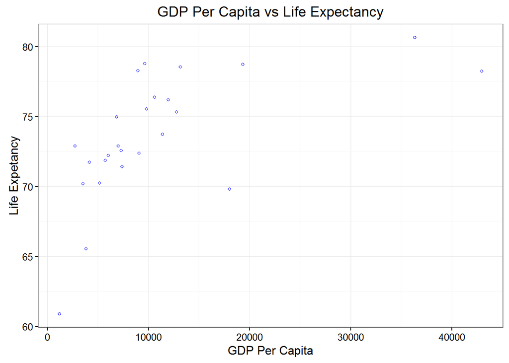

```r
ggplot(Americas, aes(x = gdpPercap, y = lifeExp)) +
  geom_point(color = "blue", shape=1, size = 1) + theme_bw() +
  xlab("GDP Per Capita") + ylab("Life Expetancy") +
  ggtitle("GDP Per Capita vs Life Expectancy")
```

```r
library(fastcluster) #makes hclust() runs faster
```

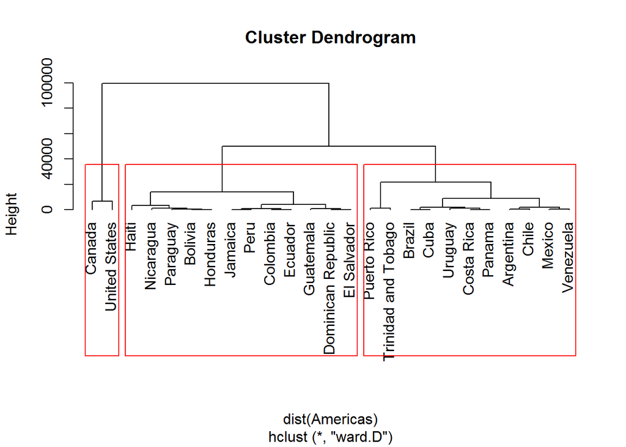

```r
Americas_hclust <- hclust(dist(Americas), method="ward.D")

#Looks up the hclust help file
# ?stats::hclust
#Dendrogram
plot(Americas_hclust, hang = -1)
# draw dendogram with red borders around 2 clusters
# try 3 clusters to see the difference
rect.hclust(Americas_hclust, k=3, border="red")
```

```r
#rect.hclust(Americas_hclust, k=4, border="red")
#rect.hclust(Americas_hclust, k=5, border="red")
#rect.hclust(Americas_hclust, k=6, border="red")
```

#### Different distance methods:

Ward’s minimum variance method aims at finding compact, spherical clusters. option “ward.D2” implements that criterion (Murtagh and Legendre 2014). With the latter, the dissimilarities are squared before cluster updating. The complete linkage method finds similar clusters. The single linkage method (which is closely related to the minimal spanning tree) adopts a ‘friends of friends’ clustering strategy. The other methods can be regarded as aiming for clusters with characteristics somewhere between the single and complete link methods.

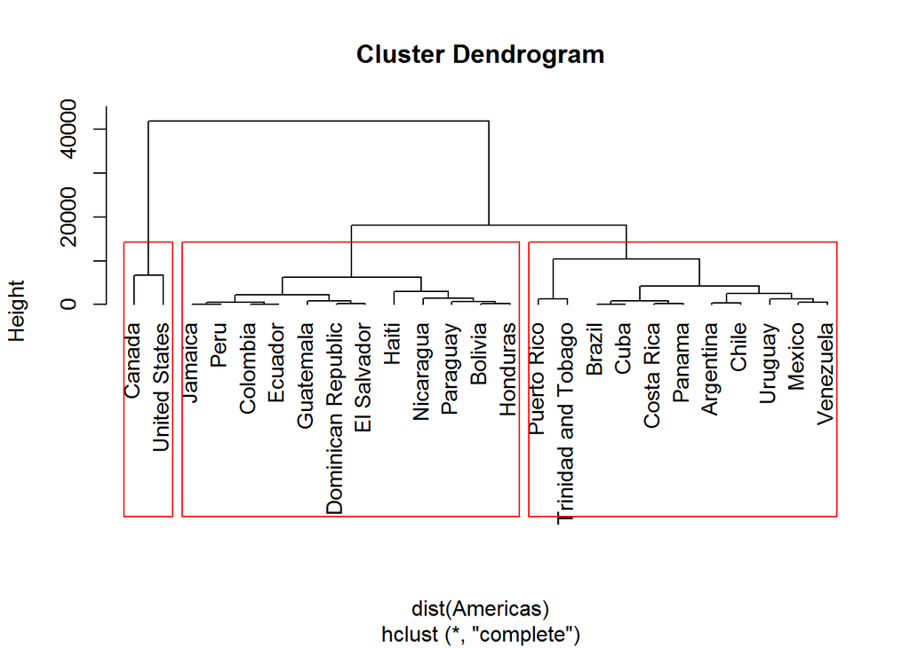

```r
Americas_hclust <- hclust(dist(Americas), method="complete")
plot(Americas_hclust, hang = -1)
rect.hclust(Americas_hclust, k=3, border="red")
```

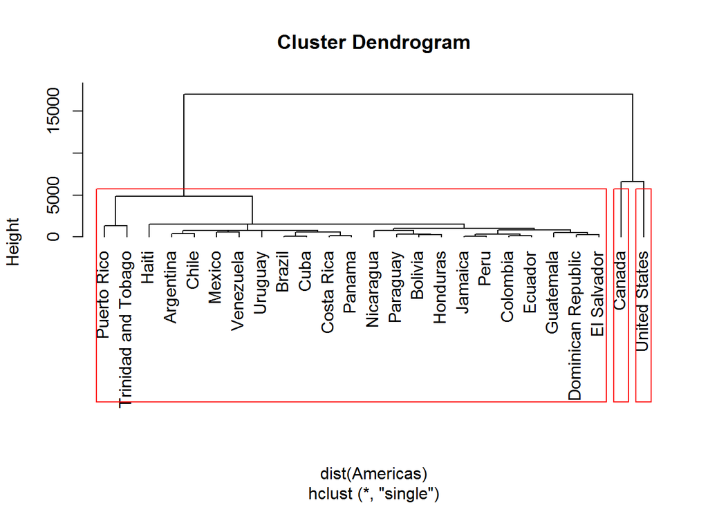

```r
Americas_hclust <- hclust(dist(Americas), method="single")
plot(Americas_hclust, hang = -1)
rect.hclust(Americas_hclust, k=3, border="red")
```

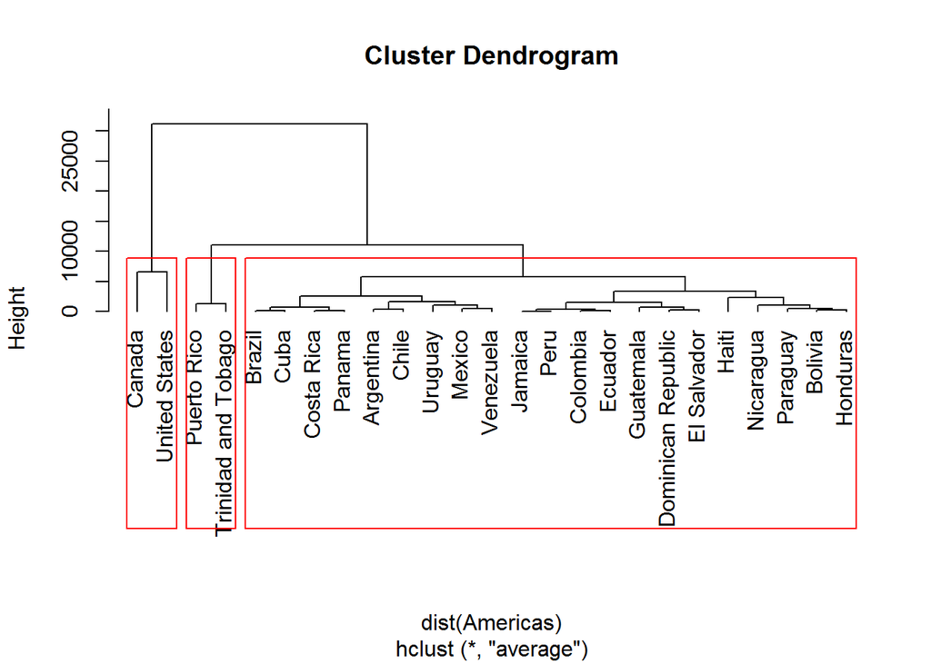

```r
Americas_hclust <- hclust(dist(Americas), method="average")
plot(Americas_hclust, hang = -1)
rect.hclust(Americas_hclust, k=3, border="red")
```

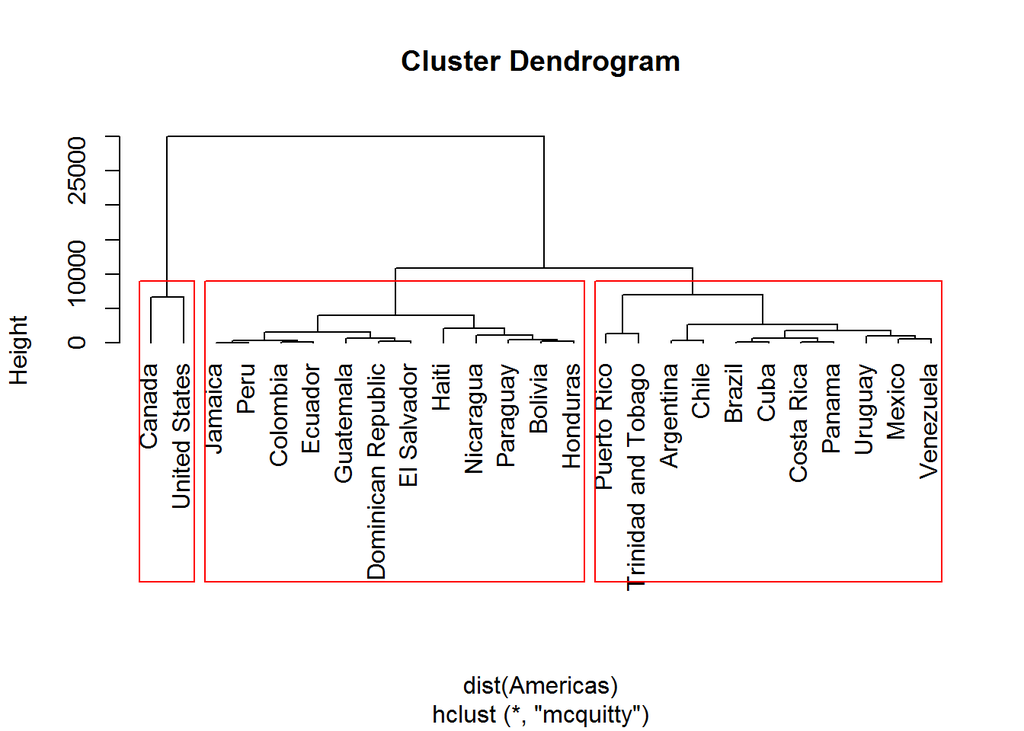

```r
Americas_hclust <- hclust(dist(Americas), method="mcquitty")
plot(Americas_hclust, hang = -1)
rect.hclust(Americas_hclust, k=3, border="red")
```

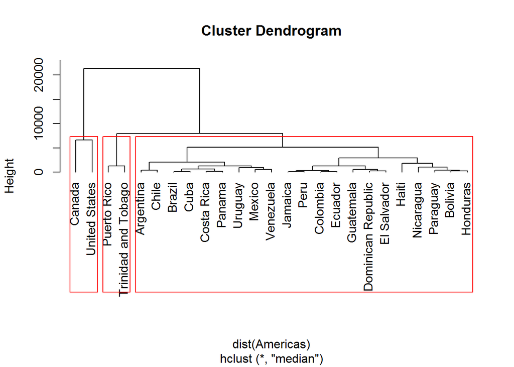

```r
Americas_hclust <- hclust(dist(Americas), method="median")
plot(Americas_hclust, hang = -1)
rect.hclust(Americas_hclust, k=3, border="red")
```

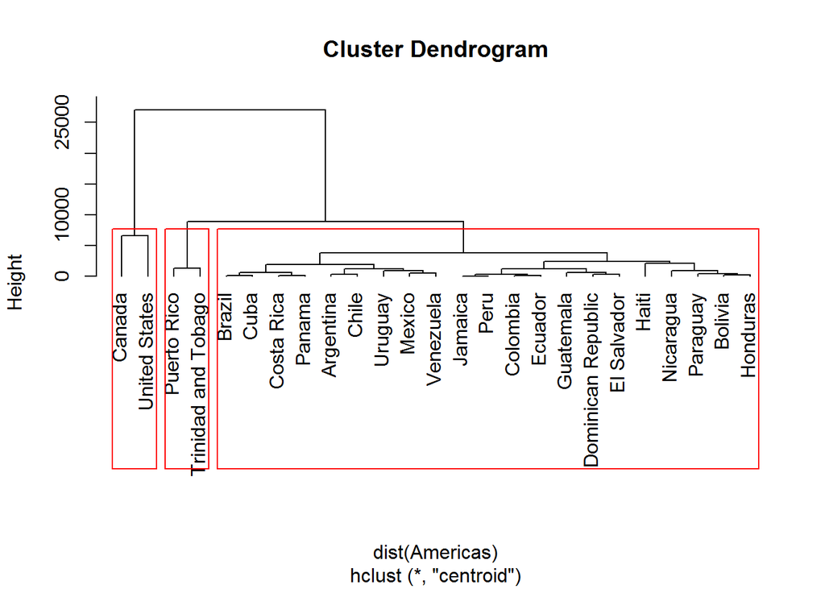

```r
Americas_hclust <- hclust(dist(Americas), method="centroid")
plot(Americas_hclust, hang = -1)
rect.hclust(Americas_hclust, k=3, border="red")
```

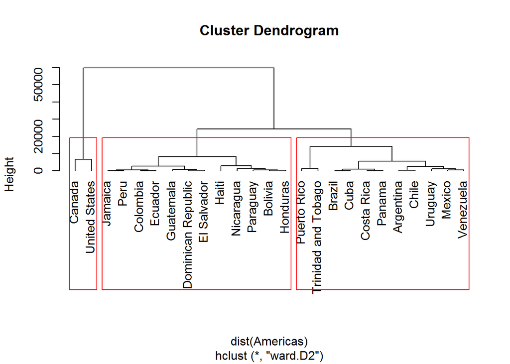

```r
Americas_hclust <- hclust(dist(Americas), method="ward.D2")
plot(Americas_hclust, hang = -1)
rect.hclust(Americas_hclust, k=3, border="red")
```

```r
#This gives us the height of each node in the dendrogram.
height <- Americas_hclust$height
height
```

```
##  [1]    88.03276   117.84484   133.33471   164.15629   273.84562
##  [6]   297.02145   392.27253   561.77460   563.05497   601.00682
## [11]   797.68615  1018.47980  1253.11365  1320.22995  1345.32611
## [16]  2541.54779  2788.22785  2999.78399  5532.16176  6632.41852
## [21]  8231.60347 14189.82160 24271.50295 59702.70824
```

```r
#This creates a vector with a 0 for the mininum height (bottom of tree) and without the highest height (1 cluster; top of tree)
# add first 0 and remove last item
height.2 <- c(0,height[-length(height)])
height.2
```

```
##  [1]     0.00000    88.03276   117.84484   133.33471   164.15629
##  [6]   273.84562   297.02145   392.27253   561.77460   563.05497
## [11]   601.00682   797.68615  1018.47980  1253.11365  1320.22995
## [16]  1345.32611  2541.54779  2788.22785  2999.78399  5532.16176
## [21]  6632.41852  8231.60347 14189.82160 24271.50295
```

```r
#Find the largest increase in distance
round(height-height.2,3)
```

```
##  [1]    88.033    29.812    15.490    30.822   109.689    23.176    95.251
##  [8]   169.502     1.280    37.952   196.679   220.794   234.634    67.116
## [15]    25.096  1196.222   246.680   211.556  2532.378  1100.257  1599.185
## [22]  5958.218 10081.681 35431.205
```

```r
#Find the step with the largest increase
max(round(height-height.2,3))
```

```
## [1] 35431.21
```

#### Dissimilarity matrix contains the dissimilarity between the data points. Dissimilarity is also referred to as “distance.” The default distance measure for function dist() in R is Euclidean. The function dist() is used to create the dissimilarity matrix.

Size of the matrix is calculated as follows (n k) combation: n!/(2! * (n-2)!) = (n*n-1)/2

```r
factorial(25)/(2*factorial(23))
```

```
## [1] 300
```

```r
25*(25-1)/2
```

```
## [1] 300
```

```r
library(cluster)
dissimilarity.matrix <- dist(as.matrix(Americas, method="euclidean"))
#dissimilarity.matrix
americas_pam <- pam(dissimilarity.matrix,3)
summary(americas_pam) #Look at the assigned cluster for each data value and it nearest neighboring cluster
```

```
## Medoids:
##      ID
## [1,] "25" "Venezuela"
## [2,] "11" "El Salvador"
## [3,] "23" "United States"
## Clustering vector:
##           Argentina             Bolivia              Brazil
##                   1                   2                   1
##              Canada               Chile            Colombia
##                   3                   1                   2
##          Costa Rica                Cuba  Dominican Republic
##                   1                   1                   2
##             Ecuador         El Salvador           Guatemala
##                   2                   2                   2
##               Haiti            Honduras             Jamaica
##                   2                   2                   2
##              Mexico           Nicaragua              Panama
##                   1                   2                   1
##            Paraguay                Peru         Puerto Rico
##                   2                   2                   1
## Trinidad and Tobago       United States             Uruguay
##                   1                   3                   1
##           Venezuela
##                   1
## Objective function:
##    build     swap
## 2397.551 2140.069
##
## Numerical information per cluster:
##      size max_diss  av_diss  diameter separation
## [1,]   11 7912.905 2471.475 10380.606   1539.213
## [2,]   12 4526.730 1640.256  6207.277   1539.213
## [3,]    2 6632.419 3316.209  6632.419  16990.526
##
## Isolated clusters:
##  L-clusters: character(0)
##  L*-clusters: [1] 3
##
## Silhouette plot information:
##                     cluster neighbor  sil_width
```

[output cut: 18 more lines]

```
## Haiti                     2        1 0.61639857
## Ecuador                   2        1 0.59988875
## Colombia                  2        1 0.57585254
## Jamaica                   2        1 0.50244898
## Peru                      2        1 0.47687763
## United States             3        1 0.78396476
## Canada                    3        1 0.72443247
## Average silhouette width per cluster:
## [1] 0.4235036 0.6581315 0.7541986
## Average silhouette width of total data set:
## [1] 0.5625806
##
## Available components:
## [1] "medoids"    "id.med"     "clustering" "objective"  "isolation"
## [6] "clusinfo"   "silinfo"    "diss"       "call"
```

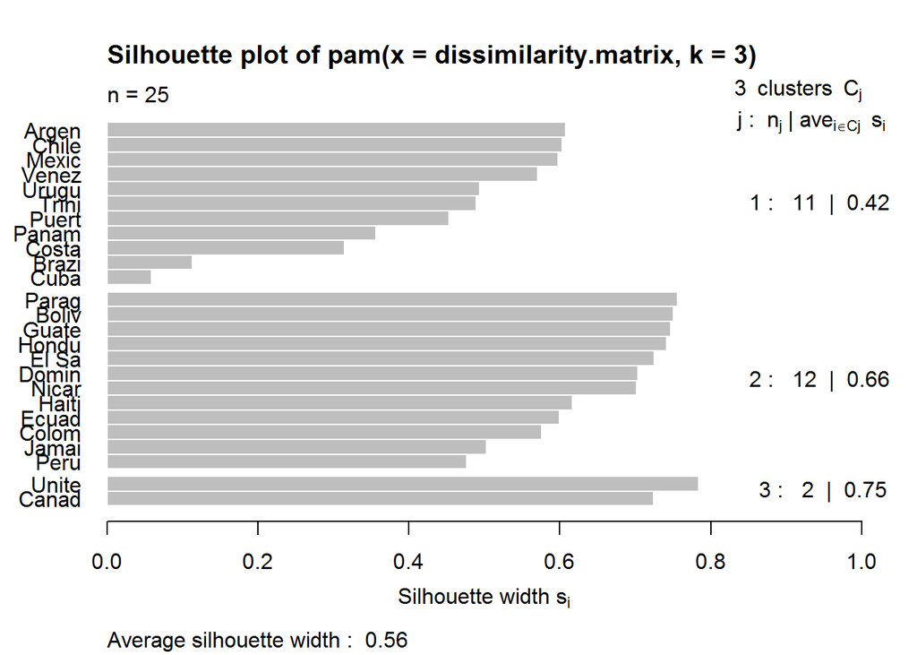

```r
plot(americas_pam) #Silhouette Plot
```

END